# CTC Pre-matriculation Social Belonging Intervention Report for SCHOOL NAME.

## Outcomes

We collected some survey outcomes after the intervention. They were pretty neat.

### Psychometric Characteristics

mindset

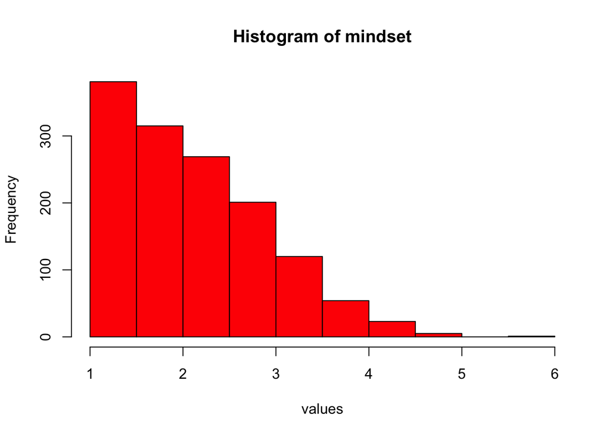

grit

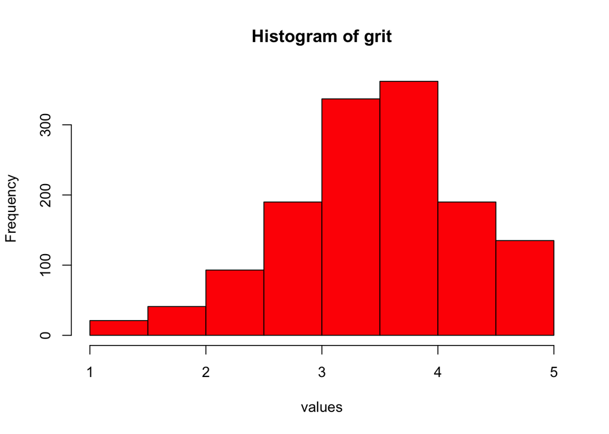

institutional_mindset

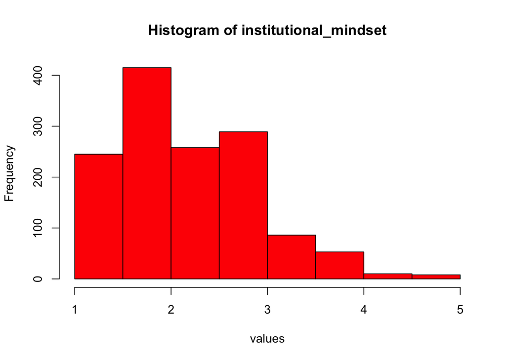

excitement

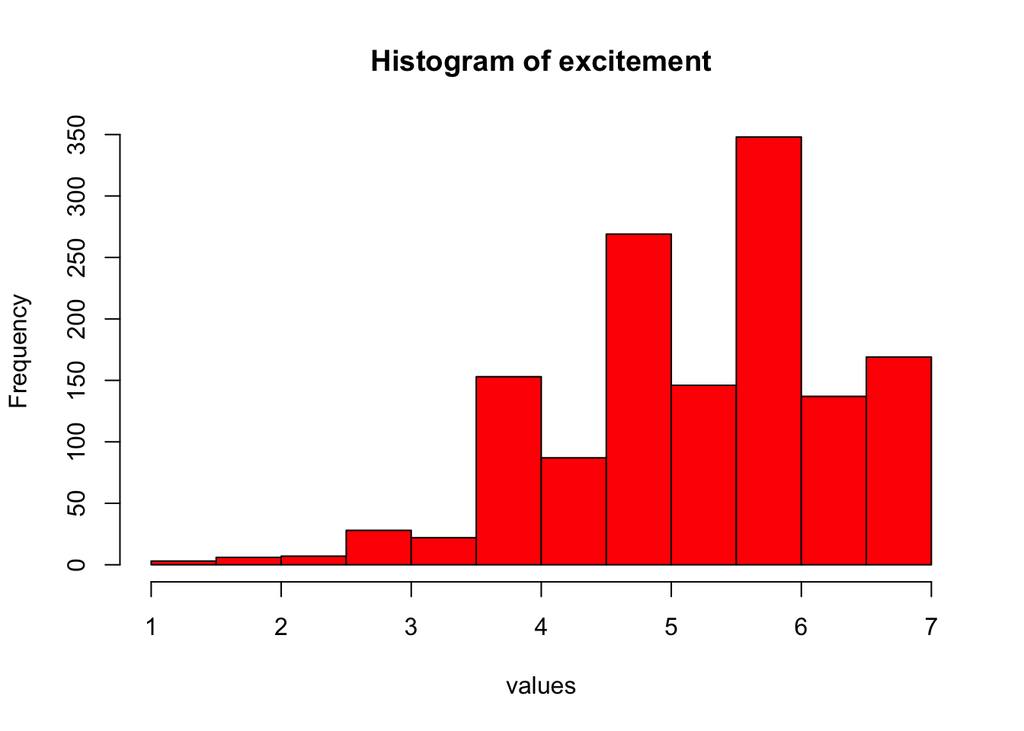

difficulty

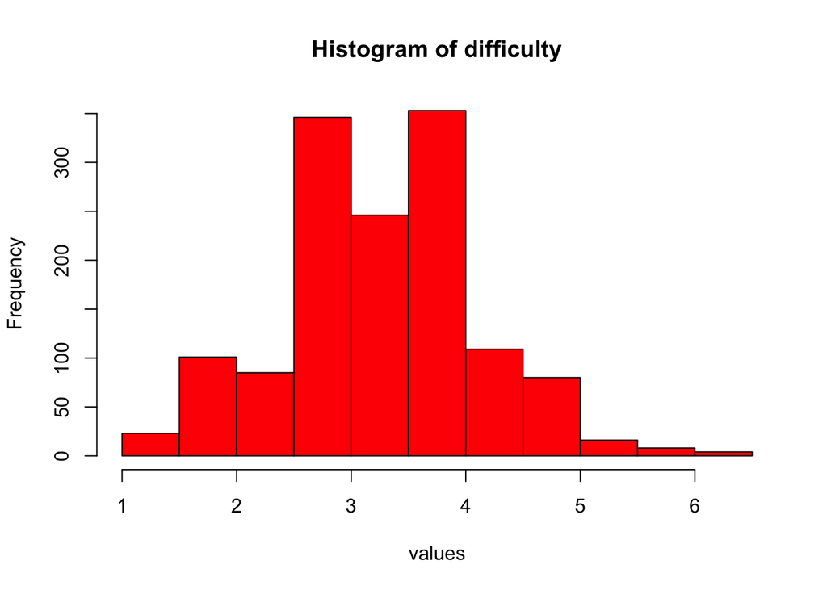

froshsoph belonging

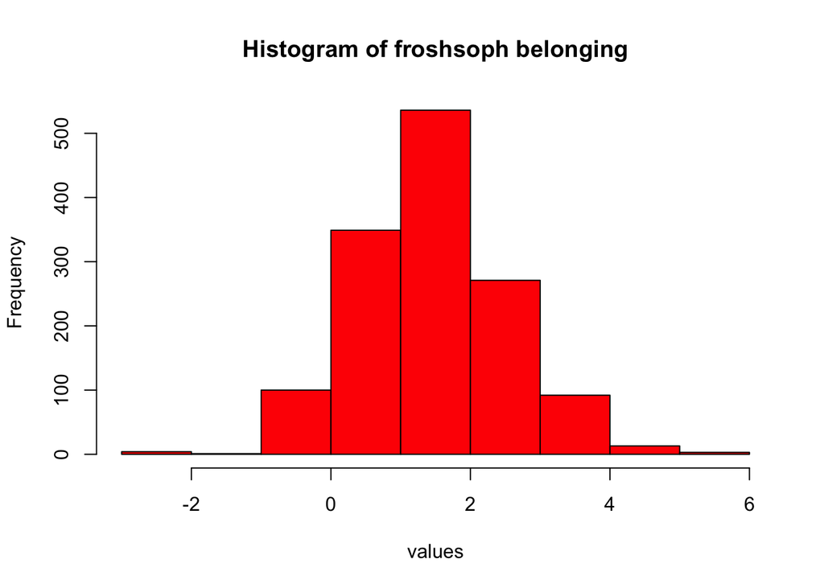

learned_anything

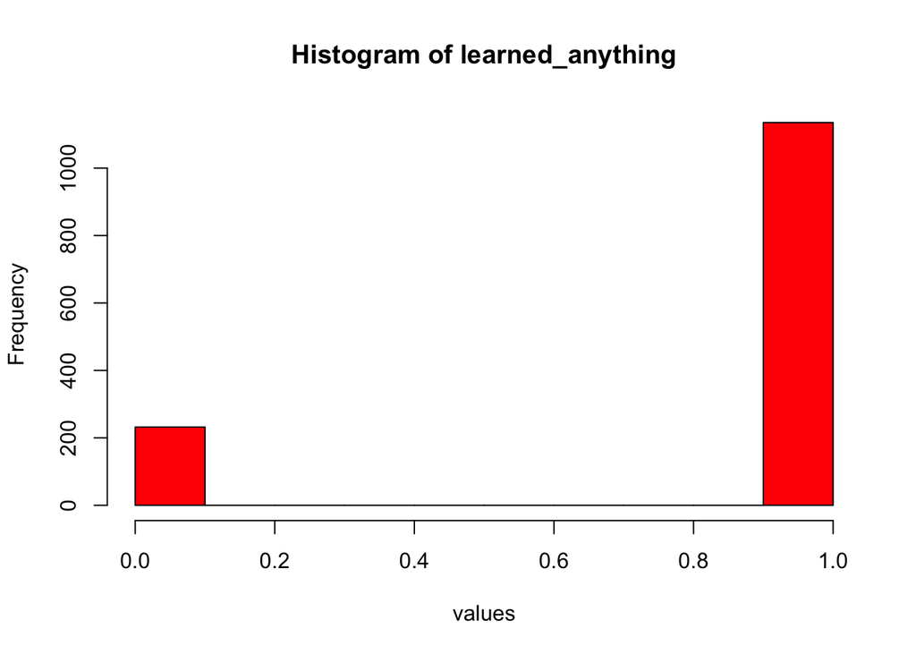